# Unit9HW

Quentin Thomas

3/5/2018

## MSDS 6306 Preparing Data

### Questions

1. **Harry Potter Casts**

`a.` In the IMDB, there are listings of full cast members for movies. Navigate to [link](http://www.imdb.com/title/tt1201607/fullcredits?ref_=tt_ql_1). Feel free to View Source to get a good idea of what the page looks like in the code.

`b.` Scrape the page with any R package that makes things easy for you. Of particular interest is the table of the Cast in order of crediting. Please scrape this table (You might have to fish it out of several of the tables from the page) and make it a data.frame() of the Cast in your R environment.

```r
library(rvest)
page_data <- read_html(x = "http://www.imdb.com/title/tt1201607/fullcredits?ref_=tt_ql_1")
page_table <- html_node(page_data, xpath = "/html/body/div[1]/div/div[4]/div[3]/div[1]/div[1]/div[2]/table[3]")
casts <- html_table(page_table)
casts
```

```
##                                      X1
## 1
## 2
## 3
## 4
## 5
## 6
## 7
## 8
## 9
## 10
## 11
## 12
## 13
## 14
```

[output cut: 593 more lines]

`c.` clean up the table

- It should not have blank observations or rows, a row that should be column names, or just ‘…’

```r
library(stringr)
casts <- casts[, c(2,4)]
casts <- casts[-1,]
casts$X4 <- str_replace_all(casts$X4, "[\r\n]" , "")
```

- It should have intuitive column names (ideally 2 to start - Actor and Character)

```r
names(casts) <- c("Actor", "Character")
```

- In the film, Mr Warwick plays two characters which makes his row look a little weird. Please replace his character column with just “Griphook/Professor Filius Flitwick” to make it look better

```r
casts[grepl(pattern = "^Warwick", casts$Actor),]$Character <- "Griphook/Professor Filius Flitwick"
```

- One row might result in “Rest of cast listed alphabetically” - remove this observation.

```r
casts <- casts[!c(casts$Actor == "Rest of cast listed alphabetically:"),]
casts
```

```
##                             Actor
## 2                   Ralph Fiennes
## 3                  Michael Gambon
## 4                    Alan Rickman
## 5                Daniel Radcliffe
## 6                    Rupert Grint
## 7                     Emma Watson
## 8                    Evanna Lynch
## 9                Domhnall Gleeson
## 10                 Clémence Poésy
## 11                  Warwick Davis
## 12                      John Hurt
## 13           Helena Bonham Carter
## 14                    Graham Duff
## 15                Anthony Allgood
```

[output cut: 285 more lines]

`d.` Split the Actor’s name into two columns: FirstName and Surname. Keep in mind that some actors/actresses have middle names as well. Please make sure that the middle names are in the FirstName column, in addition to the first name(example: given the Actor Frank Jeffrey Stevenson, the Firstname column would say “Frank Jeffrey.”)

```r
#Need to split off the last names from the rest of the names so that it will also include middle names if they have it.
split_names <- str_split(casts$Actor, pattern = " (?=[^ ]+$)")
d <- data.frame(matrix(unlist(split_names), nrow=149, byrow=T),stringsAsFactors=FALSE)
names(d) <- c("FirstName","Surname")
casts <- cbind(d, casts$Character)
names(casts)[1] <- "FirstName"
names(casts)[3] <- "Character"
```

`e.` Present the first 10 rows of the data.frame()- It should have only FirstName, Surname, and Character Columns.

```r
head(casts, 10)
```

```
##    FirstName   Surname                          Character
## 1      Ralph   Fiennes                     Lord Voldemort
## 2    Michael    Gambon         Professor Albus Dumbledore
## 3       Alan   Rickman            Professor Severus Snape
## 4     Daniel Radcliffe                       Harry Potter
## 5     Rupert     Grint                        Ron Weasley
## 6       Emma    Watson                   Hermione Granger
## 7     Evanna     Lynch                      Luna Lovegood
## 8   Domhnall   Gleeson                       Bill Weasley
## 9   Clémence     Poésy                     Fleur Delacour
## 10   Warwick     Davis Griphook/Professor Filius Flitwick
```

2. **SportsBall**

`a.` On the ESPN website, there are statistics of each NBA player. Navigate to the San Antonio Spurs current statistics [link](http://www.espn.com/nba/team/stats/_/name/sa/san-antonio-spurs). You are interested in the `Shooting Statistics` table.

`b.` Scrape the page with any R package that makes things easy for you. There are a few tables on the page, so make sure you are targeting specifically the Shooting statistics table.

```r
#scraping all the data!
espn_data <- read_html(x = "http://www.espn.com/nba/team/stats/_/name/sa/san-antonio-spurs")
espn_table <- html_node(espn_data, css ="#my-players-table > div.mod-container.mod-table > div:nth-child(3) > table")
shooting_stats <- html_table(espn_table)
shooting_stats
```

```
##                       X1                  X2                  X3
## 1    SHOOTING STATISTICS SHOOTING STATISTICS SHOOTING STATISTICS
## 2                 PLAYER                 FGM                 FGA
## 3  LaMarcus Aldridge, PF                 8.7                17.5
## 4      Kawhi Leonard, SF                 5.8                12.3
## 5           Rudy Gay, SF                 4.3                 9.1
## 6           Pau Gasol, C                 4.0                 8.6
## 7        Patty Mills, PG                 3.3                 8.0
## 8      Manu Ginobili, SG                 3.3                 7.6
## 9        Danny Green, SG                 3.3                 8.1
## 10       Tony Parker, PG                 3.8                 7.9
## 11     Kyle Anderson, SF                 3.2                 6.1
## 12   Dejounte Murray, PG                 3.1                 7.1
## 13       Bryn Forbes, SG                 2.8                 6.7
## 14      Davis Bertans, C                 2.3                 5.1
```

[output cut: 90 more lines]

`c.` Clean up the table (You might get some warnings if you’re working with tibbles) - You’ll want to create an R data.frame() with one observation for each player. Make sure that you do not accidentally include blank rows, a row of column names, or the Totals row in the table as observations.

```r
#Remove SHooting Stats CSS nonsense that is cluttering up my dataframe
shooting_stats <- shooting_stats[-1,]
#Replacing the label generic x labels with the actual header values as the column names
colnames(shooting_stats) <-as.character(unlist(shooting_stats[1,]))
shooting_stats <- shooting_stats[-1,]
#Removing totals row
shooting_stats <- shooting_stats[-nrow(shooting_stats),]
shooting_stats
```

```
##                   PLAYER FGM  FGA  FG% 3PM 3PA  3P% FTM FTA  FT% 2PM  2PA
## 3  LaMarcus Aldridge, PF 8.7 17.5 .500 0.4 1.3 .321 4.3 5.2 0.84 8.3 16.2
## 4      Kawhi Leonard, SF 5.8 12.3 .468 1.2 3.9 .314 3.4 4.2 0.82 4.6  8.4
## 5           Rudy Gay, SF 4.3  9.1 .470 0.7 2.1 .333 2.1 2.7 0.78 3.6  7.0
## 6           Pau Gasol, C 4.0  8.6 .460 0.7 1.7 .382 2.2 2.8 0.76 3.3  6.9
## 7        Patty Mills, PG 3.3  8.0 .420 1.8 4.8 .379 1.2 1.4 0.88 1.5  3.2
## 8      Manu Ginobili, SG 3.3  7.6 .437 1.0 3.2 .327 1.6 1.9 0.86 2.3  4.4
## 9        Danny Green, SG 3.3  8.1 .409 1.8 4.6 .385 0.7 0.9 0.78 1.5  3.5
## 10       Tony Parker, PG 3.8  7.9 .483 0.1 0.7 .192 1.0 1.5 0.67 3.7  7.2
## 11     Kyle Anderson, SF 3.2  6.1 .523 0.2 0.7 .297 1.6 2.1 0.74 3.0  5.4
## 12   Dejounte Murray, PG 3.1  7.1 .439 0.1 0.3 .238 1.2 1.6 0.73 3.0  6.8
## 13       Bryn Forbes, SG 2.8  6.7 .414 1.2 3.2 .376 0.5 0.9 0.61 1.6  3.5
## 14      Davis Bertans, C 2.3  5.1 .443 1.3 3.5 .367 0.6 0.8 0.80 1.0  1.6
## 15  Joffrey Lauvergne, C 2.0  3.8 .531 0.0 0.1 .000 0.7 1.0 0.65 2.0  3.7
## 16     Derrick White, PG 0.8  1.6 .480 0.3 0.5 .500 0.8 1.1 0.67 0.5  1.1
```

[output cut: 21 more lines]

- The Column PLAYER has two variables of Interests in it: the player’s name and their position, denoted by 1-2 letters after their name. Split the cells into two columns, one with Name and the other Position.

```r
names_and_pos <- str_split(shooting_stats$PLAYER, ", ")
df <-  data.frame(matrix(unlist(names_and_pos), nrow=17, byrow=T),stringsAsFactors=FALSE)
names(df) <- c("Player", "Position")
df
```

```
##               Player Position
## 1  LaMarcus Aldridge       PF
## 2      Kawhi Leonard       SF
## 3           Rudy Gay       SF
## 4          Pau Gasol        C
## 5        Patty Mills       PG
## 6      Manu Ginobili       SG
## 7        Danny Green       SG
## 8        Tony Parker       PG
## 9      Kyle Anderson       SF
## 10   Dejounte Murray       PG
## 11       Bryn Forbes       SG
## 12     Davis Bertans        C
## 13 Joffrey Lauvergne        C
## 14     Derrick White       PG
## 15      Brandon Paul       SG
## 16   Darrun Hilliard       SG
## 17     Matt Costello       SF
```

```r
stats <- shooting_stats[, c(2:15)]
sa_playerstats <- cbind(df, stats)
sa_playerstats
```

```
##               Player Position FGM  FGA  FG% 3PM 3PA  3P% FTM FTA  FT% 2PM
## 3  LaMarcus Aldridge       PF 8.7 17.5 .500 0.4 1.3 .321 4.3 5.2 0.84 8.3
## 4      Kawhi Leonard       SF 5.8 12.3 .468 1.2 3.9 .314 3.4 4.2 0.82 4.6
## 5           Rudy Gay       SF 4.3  9.1 .470 0.7 2.1 .333 2.1 2.7 0.78 3.6
## 6          Pau Gasol        C 4.0  8.6 .460 0.7 1.7 .382 2.2 2.8 0.76 3.3
## 7        Patty Mills       PG 3.3  8.0 .420 1.8 4.8 .379 1.2 1.4 0.88 1.5
## 8      Manu Ginobili       SG 3.3  7.6 .437 1.0 3.2 .327 1.6 1.9 0.86 2.3
## 9        Danny Green       SG 3.3  8.1 .409 1.8 4.6 .385 0.7 0.9 0.78 1.5
## 10       Tony Parker       PG 3.8  7.9 .483 0.1 0.7 .192 1.0 1.5 0.67 3.7
## 11     Kyle Anderson       SF 3.2  6.1 .523 0.2 0.7 .297 1.6 2.1 0.74 3.0
## 12   Dejounte Murray       PG 3.1  7.1 .439 0.1 0.3 .238 1.2 1.6 0.73 3.0
## 13       Bryn Forbes       SG 2.8  6.7 .414 1.2 3.2 .376 0.5 0.9 0.61 1.6
## 14     Davis Bertans        C 2.3  5.1 .443 1.3 3.5 .367 0.6 0.8 0.80 1.0
## 15 Joffrey Lauvergne        C 2.0  3.8 .531 0.0 0.1 .000 0.7 1.0 0.65 2.0
## 16     Derrick White       PG 0.8  1.6 .480 0.3 0.5 .500 0.8 1.1 0.67 0.5
```

[output cut: 21 more lines]

- Check the data type of all columns. convert relevant columns to numeric. Check the data type of all columns again to confirm that they have changed!

Data types of relevant columns BEFORE conversion.

```r
sapply(sa_playerstats, mode)
```

```
##      Player    Position         FGM         FGA         FG%         3PM
## "character" "character" "character" "character" "character" "character"
##         3PA         3P%         FTM         FTA         FT%         2PM
## "character" "character" "character" "character" "character" "character"
##         2PA         2P%         PPS        AFG%
## "character" "character" "character" "character"
```

Data types of relevant columns After conversion

```r
stats <- as.data.frame(sapply(sa_playerstats[,c(3:16)], as.numeric))
sa_playerstats <- cbind(df, stats)
sapply(sa_playerstats, mode)
```

```
##      Player    Position         FGM         FGA         FG%         3PM
## "character" "character"   "numeric"   "numeric"   "numeric"   "numeric"
##         3PA         3P%         FTM         FTA         FT%         2PM
##   "numeric"   "numeric"   "numeric"   "numeric"   "numeric"   "numeric"
##         2PA         2P%         PPS        AFG%
##   "numeric"   "numeric"   "numeric"   "numeric"
```

`d.` Create a colorful bar chart that shows the Field Goals Percentage per game for each person. It will be graded on the following criteria.

- Informative Title, centered
- Relevant x and y axis labels (not simply variables names!)
- Human-readable axes with no overlap(you might have to flip x and y to fix that)
- Color the columns by the team member’s position (so, all PF’s should have the same color, etc.)

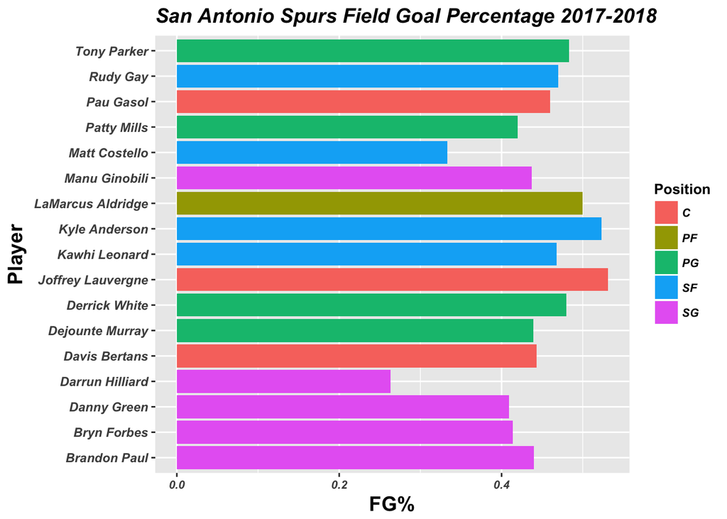

```r
library(ggplot2)

sports_theme <- theme(plot.title = element_text(face = "bold.italic",
                                                size= 14,
                                                color = "black"),
                      axis.text.x = element_text(size = 8, face = "bold.italic"),
                      axis.text.y = element_text(face = "bold.italic"),
                      legend.text = element_text(face = "bold.italic", color = "black", size = 8),
                      legend.title = element_text(face = "bold", color ="black", size = 10),
                      axis.title.x = element_text(face= "bold", color = "black", size = 14),
                      axis.title.y = element_text(face="bold", color = "black", size = 14))

ggplot(data = sa_playerstats, aes(x = Player, y = `FG%`, fill = Position)) +
  geom_bar(stat = "identity", position = position_stack(reverse = TRUE)) +
  coord_flip() +
  labs(title = "San Antonio Spurs Field Goal Percentage 2017-2018") +
  sports_theme
```